# deconvolution_diagnosis

2026-01-22

```r
knitr::opts_chunk$set(echo = TRUE)
library(tidyr)
library(dplyr)
library(tibble)
```

```r
library(ggplot2)
library(MotrpacHumanPreSuspensionData)
library(MotrpacHumanPreSuspensionAnalysis)
config = jsonlite::fromJSON("~/config.json")
repo_local_dir = config$precovid_repo_path

source("deconv_helpers.R")
```

## Algorithm choice

We use `cibersortx.stanford.edu` ’s webpage for deconvolution which doesn’t have a direct R package implementation that I’ve found.

### Reference resolution

Another important consideration is the resolution the reference is at—some references will try and be exceptionally precise in terms of the cell type (e.g. try to differentiation signal between Tregs and Gamma T cells), but this level of precision is (1) Not that useful for our study, (2) leads to instability in some models, depending on the algorithm used. The cibersort results document gives some information for correlation to marker genes and the correlation is not that great in many circumstances. I am worried that the low representation + high variance is not appropriate.

For (1) - Any clinical measurements or decision making is not going to have cells profiled at an extremely high specificity, so, even if the algorithm is exactly correct, knowing differences between resting and activated Dendritic cells doesn’t help with the research question that we’re approaching.

For (2) - This is partially because of co-linearity in some very similar cell types, e.g. if activated and resting dendritic cells are 99% similar for the markers in our dataset (just hypothetically), any methods using linear model approaches can suffer from co-linearity issues.

### Note/Data loading.

```r
cibersort_results = file.path(repo_local_dir,
                              "figures",
                              "blood",
                              "final_figure_input_data_files",
                              "CIBERSORTx_PrecovidBlood_RNADecon_Results.csv")
cibersort_results = read.csv(cibersort_results)
```

For a more direct comparison, I just directly draw a scatterplot for the correlation of 2 specific (similar-ish) cell types

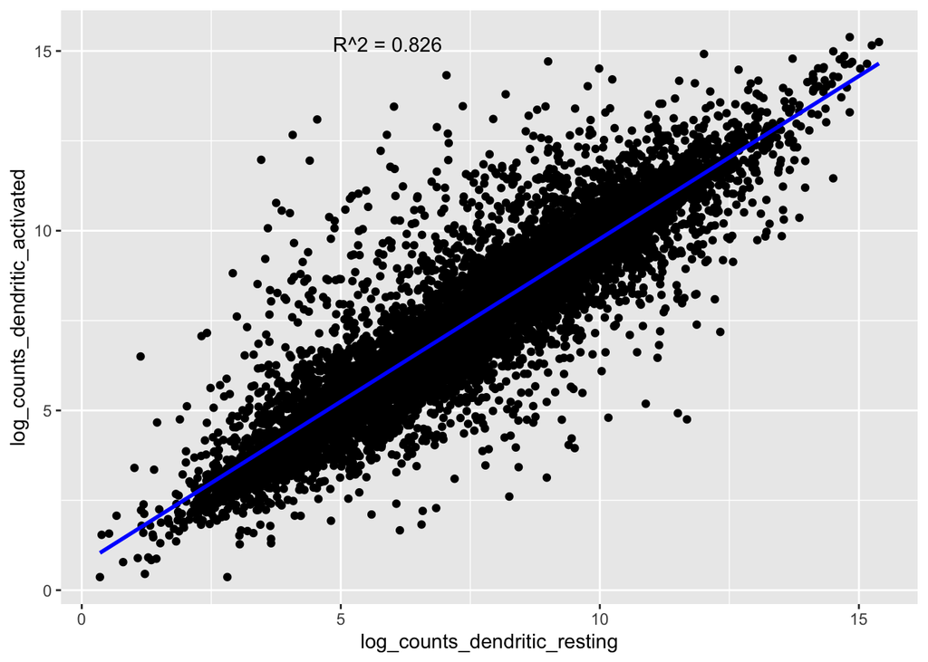

```r
signature_matrix_LM22_plot = signature_matrix_LM22 %>%
  as.data.frame() %>%
  mutate(log_counts_dendritic_resting = log2(Dendritic.cells.resting),
         log_counts_dendritic_activated = log2(Dendritic.cells.activated))

r2_value = cor(signature_matrix_LM22_plot$log_counts_dendritic_resting,
               signature_matrix_LM22_plot$log_counts_dendritic_activated)^2

p = signature_matrix_LM22_plot %>%
  ggplot(aes(x = log_counts_dendritic_resting,
             y = log_counts_dendritic_activated)) +
  geom_point() +
  geom_smooth(method = "lm", se = FALSE, color = "blue") +
  annotate("text",
           x = max(signature_matrix_LM22_plot$log_counts_dendritic_resting, na.rm = TRUE),
           y = max(signature_matrix_LM22_plot$log_counts_dendritic_activated, na.rm = TRUE),
           label = paste0("R^2 = ", round(r2_value, 3)),
           hjust = 5, vjust = 1)

print(p)
```

### Quick detour for attempting to fix this:

Here, I had a strategy to test what deconvolution results would look like if we were to condense cell types by expected cell fraction. For example, if we knew 20% of all Macrophages were ‘Macrophage.M0’, 20% were ‘Macrophage.M1’, and 60% were ‘Macrophage.M2’, we could find a weighted average that represents ‘Macrophage’. This could improve deconvolution model stability and keep results at a resolution that is appropriate for our dataset. This could be better than trying to estimate specific cell type fractions and then adding up values after the deconvolution is performed. Note: supposedly the CIBERSORT algorithm does a lot better at digesting this colinearity, and is well suited for the type of data that we have in our project.

### Actual coding implementation

To address multicolinearity and different resolutions of cell types, we combine things into different categories like this

```r
cibersort_merge_df = cibersort_results %>%
  dplyr::select(-c(P.value, Correlation, RMSE)) %>%
  squish_proportions() %>%
  dplyr::rename(vialLabel = Mixture) %>%
  dplyr::mutate(vialLabel = as.character(vialLabel))

head(cibersort_merge_df %>% dplyr::select(-vialLabel))
```

```
## # A tibble: 6 × 8
##   Eosinophils Neutrophils `T cells` `B cells` `NK cells` Monocytes Macrophages
##         <dbl>       <dbl>     <dbl>     <dbl>      <dbl>     <dbl>       <dbl>
## 1           0       0.369      30.1     13.4        13.2      40.0        0
## 2           0       0.420      47.7      8.80       10.4      26.3        0
## 3           0       0.357      36.6      7.10       19.6      31.7        0
## 4           0       0.445      33.5      7.46       22.6      24.4        1.94
## 5           0       0.599      39.2     16.4        17.2      25.6        1.65
## 6           0       0.503      37.6      4.53       16.0      34.7        0
## # ℹ 1 more variable: `Mast cells` <dbl>
```

```r
blood_qc = load_qc(selected_tissues = "blood",
                   selected_omes = "transcript-rna-seq")

blood_metadata = blood_qc$blood$`transcript-rna-seq`$sample_metadata %>%
  dplyr::mutate(vialLabel = as.character(vialLabel)) %>%
  dplyr::select(vialLabel, pid, Timepoint, randomGroupCode) %>%
  inner_join(cibersort_merge_df, by = "vialLabel") %>%
  dplyr::mutate(group_timepoint = interaction(randomGroupCode,Timepoint, sep = ".")) %>%
  dplyr::select(-Eosinophils)

desired_comparisons = .generate_contrasts_acute(blood_metadata)
```

```r
.parse_contrast_vec = function(contrast_str, coef_names) {
  contrast_vec = setNames(rep(0.0, length(coef_names)), coef_names)
  tokens = strsplit(trimws(contrast_str), "\\s*[+-]\\s*")[[1]]
  signs = c(1L, ifelse(regmatches(contrast_str, gregexpr("[+-]", contrast_str))[[1]] == "-", -1L, 1L))
  for (i in seq_along(tokens)) {
    nm = trimws(tokens[i])
    if (nm %in% coef_names) contrast_vec[nm] = contrast_vec[nm] + signs[i]
  }
  contrast_vec
}

meta_cols = c("vialLabel", "pid", "Timepoint", "randomGroupCode", "group_timepoint")
cell_cols = setdiff(colnames(blood_metadata), meta_cols)

lmer_results = purrr::map_dfr(cell_cols, function(cell_type) {
  df = blood_metadata %>%
    dplyr::select(dplyr::all_of(c("pid", "group_timepoint", cell_type))) %>%
    dplyr::rename(y = dplyr::all_of(cell_type)) %>%
    dplyr::mutate(y = pmax(pmin(qlogis(y / 100), 5), -5))

  fit = lmerTest::lmer(y ~ 0 + group_timepoint + (1 | pid), data = df)
  coef_names = names(lme4::fixef(fit))

  purrr::map_dfr(desired_comparisons, function(contrast_str) {
    L = .parse_contrast_vec(contrast_str, coef_names)
    beta = lme4::fixef(fit)
    V = as.matrix(vcov(fit))
    estimate = as.numeric(L %*% beta)
    se = as.numeric(sqrt(L %*% V %*% L))
    tstat = estimate / se
    df_satt = as.numeric(lmerTest::contest(fit, L = L, rhs = 0, joint = FALSE)[["df"]])
    p_value = 2 * pt(abs(tstat), df = df_satt, lower.tail = FALSE)
    tibble::tibble(
      cell_type = cell_type,
      contrast = contrast_str,
      p_value = p_value
    )
  })
})
lmer_results = lmer_results %>%
  dplyr::group_by(contrast) %>%
  dplyr::mutate(adj_p_value = p.adjust(p_value, method = "BH")) %>%
  dplyr::ungroup()
```

# Update: Comparing to actual clinical measurements

Motrpac has some CBC values

```r
cbc_raw = MotrpacHumanPreSuspensionData::cln_raw_local_lab_results$data
# There are 2 samples with mistaken neutrophil values (≤5). The figures below show results with and without excluding them.
```

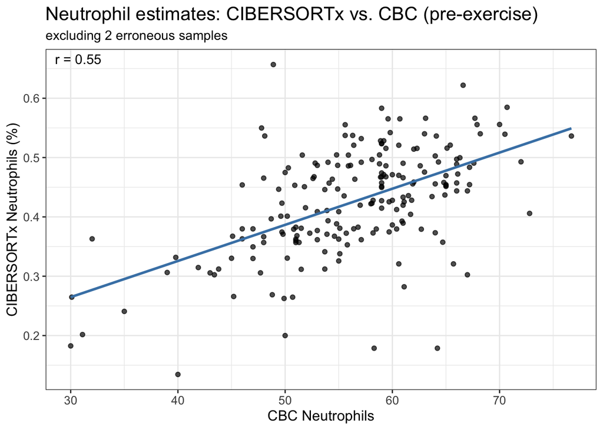

```r
# Excluding CBC neutrophil values ≤5 (2 suspected erroneous samples)
p_filtered = plot_cbc_vs_cibersortx(blood_metadata, cbc_raw, filter_lt5 = TRUE)
print(p_filtered)
```

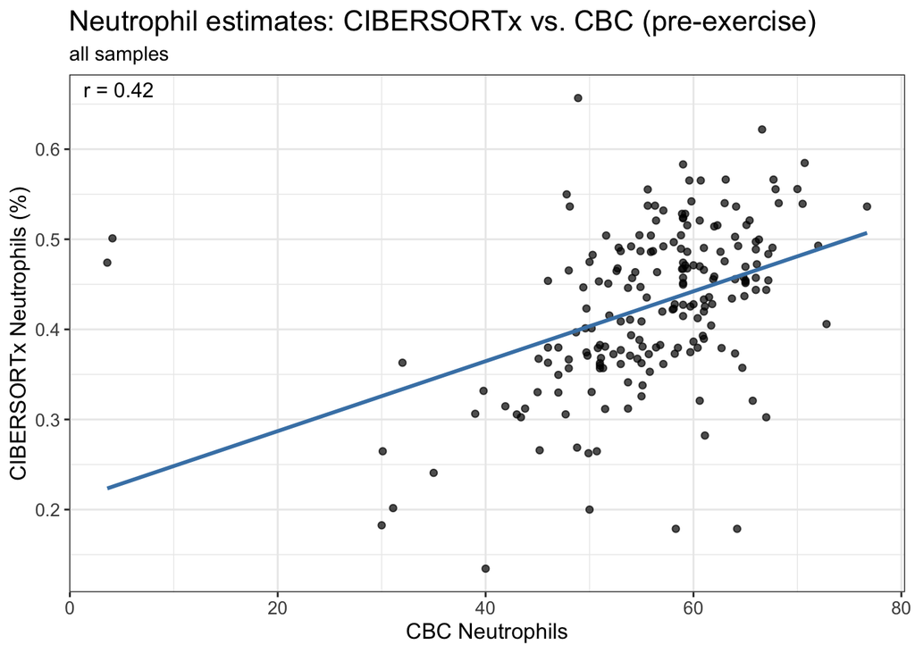

```r
# All samples included (no filter on CBC neutrophil value)
p_unfiltered = plot_cbc_vs_cibersortx(blood_metadata, cbc_raw, filter_lt5 = FALSE)
print(p_unfiltered)
```

## Adding cell types as covariates

See `DA_with_cell_types.R` to see how I’m implementing DA models with additional covariates.